# 14th August

Anna Hutchinson

14/08/2019

#### 1. UK10K Reference Panel

Aim: Investigate how the UK10K data performs as a reference panel for the 1000 Genomes data.

**NOTE: The “low” LD region comes from Africans so do not attempt to use the UK10K reference panel to correct this. Instead focus on the medium and high LD regions. This explains why the MAFs do not match up between original data (1000G) and reference data (UK10K) in the low LD region:**

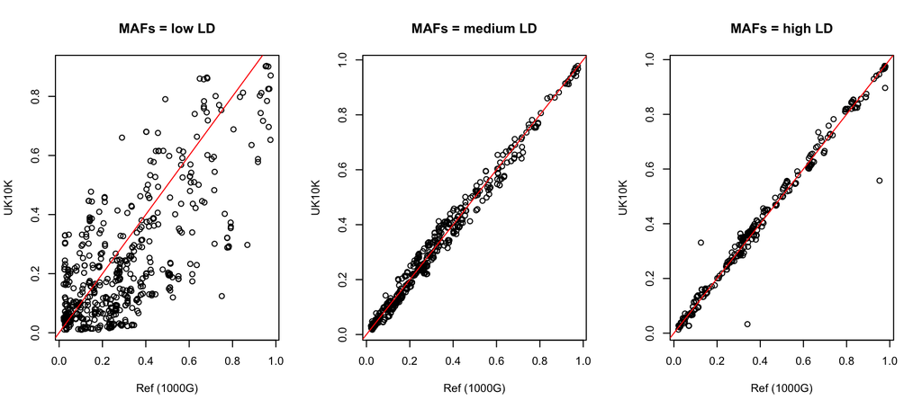

Lots of the SNPs are not found in the UK10K data (matched by position).

- Medium: 1000G haps = 1006, UK10K (ref) haps = 7562, 1000G nsnps = 706, UK10K (ref) nsnps = 578.
  - Loose 128 SNPs
- High: 1000G haps = 1006, UK10K (ref) haps = 7562, 1000G nsnps = 718, UK10K (ref) nsnps = 416.
  - Loose 302 SNPs

#### Why are so many SNPs dropped?

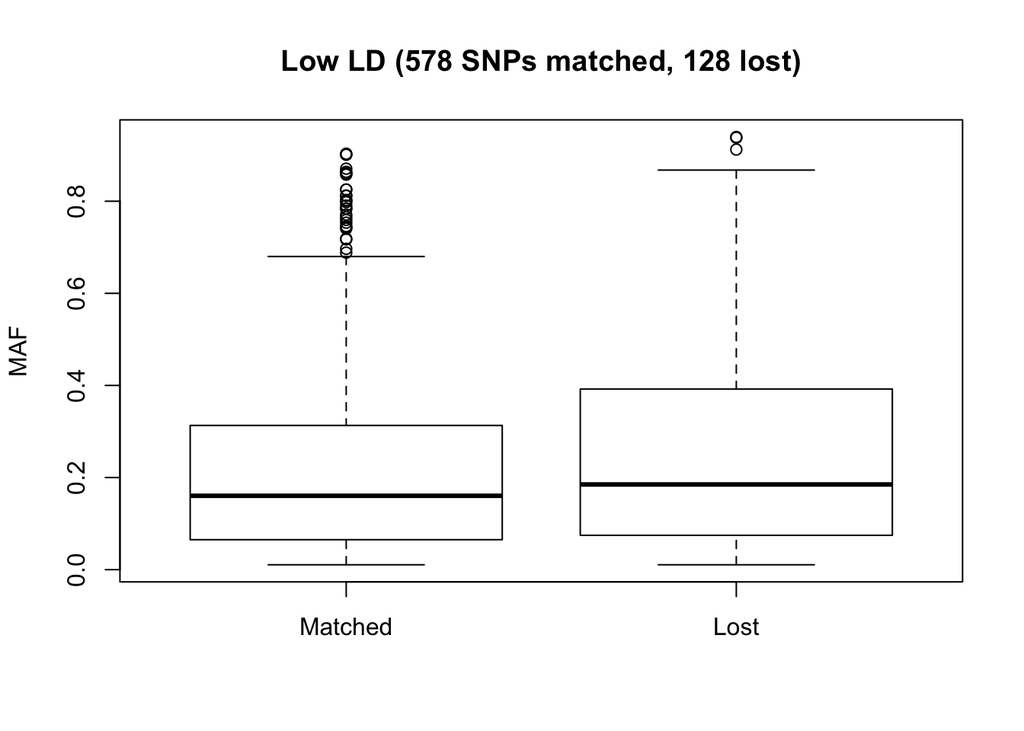

```r
lost_high <- readRDS("lost_high.RDS")
lost_low <- readRDS("lost_low.RDS")

boxplot(colMeans(lost_low$matched), colMeans(lost_low$unmatched), names = c("Matched", "Lost"), main = "Low LD (578 SNPs matched, 128 lost)", ylab = "MAF")
```

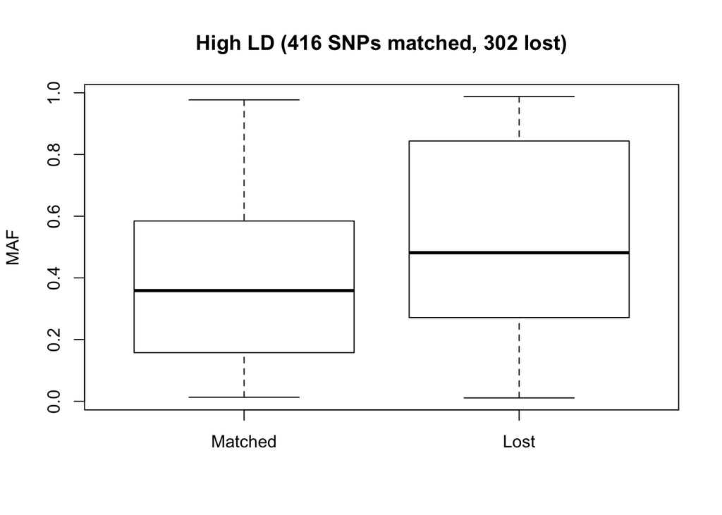

```r
boxplot(colMeans(lost_high$matched), colMeans(lost_high$unmatched), names = c("Matched", "Lost"), main = "High LD (416 SNPs matched, 302 lost)", ylab = "MAF")
```

But at least using a reference panel seems to work!

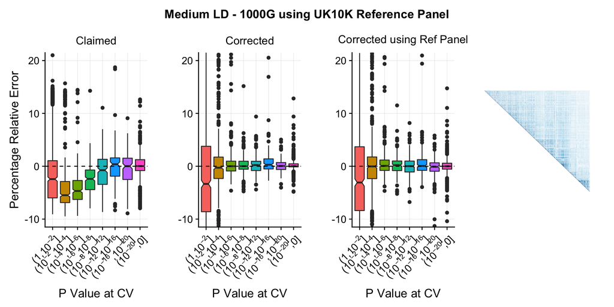

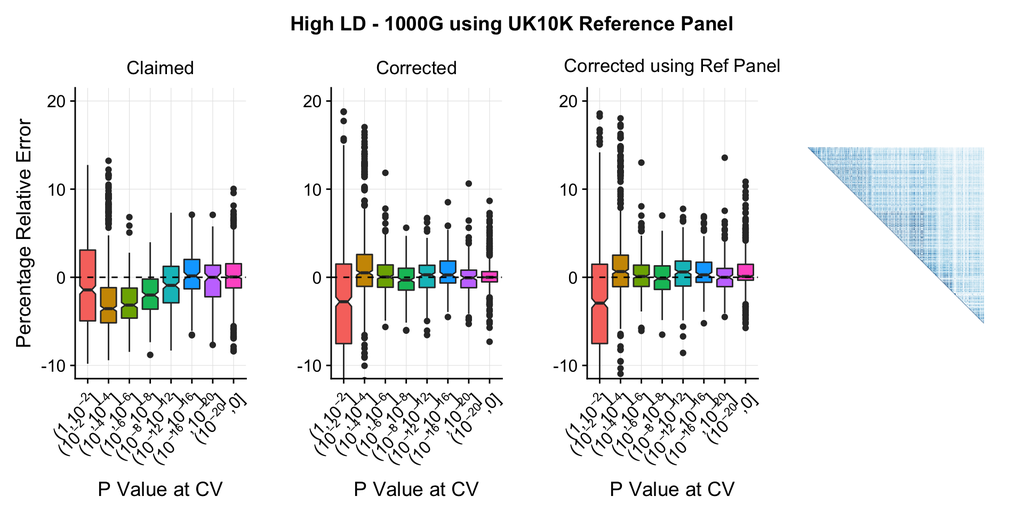

#### 2. 2 Causal Variants

##### 2 CVs in high LD ($r^2>0.7$)

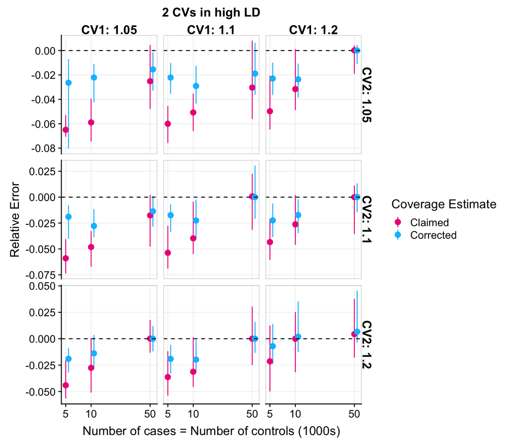

##### 2 CVs in low LD ($r^2<0.01$)

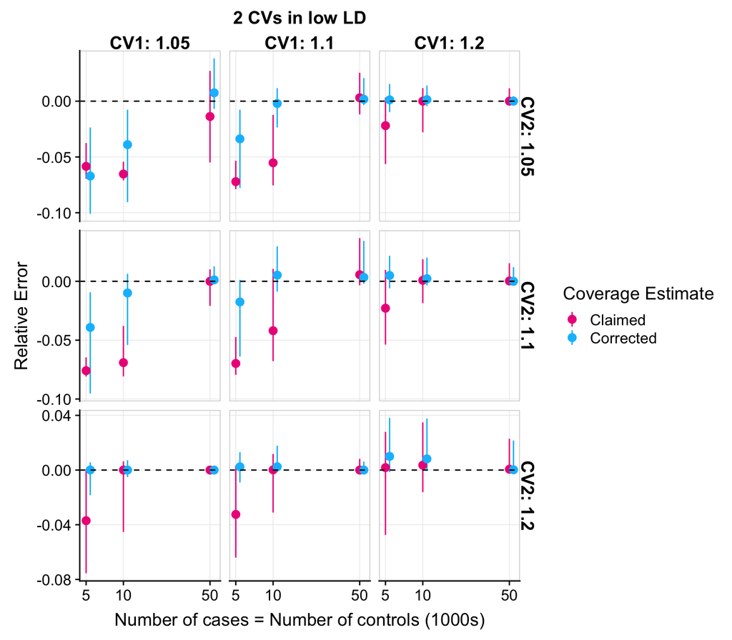

#### 3. Distribution of P values in 2 CV plot

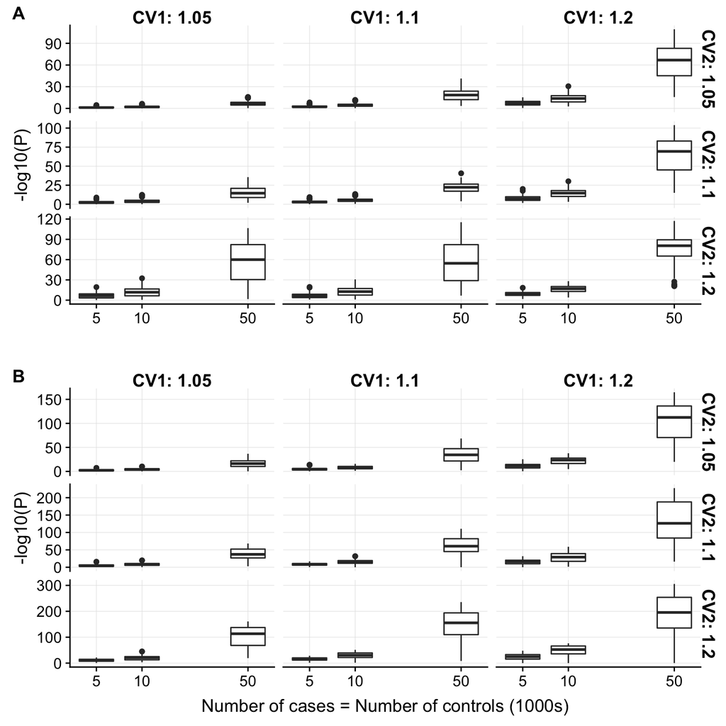